# anushab_hw4

## Homework 4 Anusha Bhat 11/24/2024

##### Please note that I used ChatGPT for debugging and code from the course notes

```python
# import libraries
from pyspark.sql import SparkSession
from pyspark.sql import functions as F
from pyspark.ml.feature import HashingTF, IDF, Tokenizer
from pyspark.ml.feature import Word2Vec
from pyspark.ml.feature import StopWordsRemover
from pyspark.sql import Row
from pyspark.ml.classification import LogisticRegression
from pyspark.ml.evaluation import MulticlassClassificationEvaluator
import pandas as pd
import matplotlib.pyplot as plt
```

```python
# start spark session
spark = SparkSession.builder.appName('Spark-Anusha-HW4').getOrCreate()
```

```python
# suppress warnings
import warnings
warnings.filterwarnings('ignore')
```

#### Question 1

```python
# 1a: read in data
df = spark.read.option("header", True) \
    .option("inferSchema", True) \
    .option("multiLine", True) \
    .option("escape", '"') \
    .option("quote", '"') \
    .csv("gs://msca-31013-bdp-ap-datasets/mpst_full_data.csv")
```

```python
df.show(10)
```

```
+---------+--------------------+--------------------+--------------------+-----+---------------+
|  imdb_id|               title|       plot_synopsis|                tags|split|synopsis_source|
+---------+--------------------+--------------------+--------------------+-----+---------------+
|tt0057603|I tre volti della...|Note: this synops...|cult, horror, got...|train|           imdb|
|tt1733125|Dungeons & Dragon...|Two thousand year...|            violence|train|           imdb|
|tt0033045|The Shop Around t...|Matuschek's, a gi...|            romantic| test|           imdb|
|tt0113862|  Mr. Holland's Opus|Glenn Holland, no...|inspiring, romant...|train|           imdb|
|tt0086250|            Scarface|In May 1980, a Cu...|cruelty, murder, ...|  val|           imdb|
|tt1315981|        A Single Man|George Falconer (...|romantic, queer, ...|  val|           imdb|
|tt0249380|           Baise-moi|Baise-moi tells t...|gothic, cruelty, ...|train|      wikipedia|
|tt0408790|          Flightplan|Kyle Pratt (Jodie...|mystery, suspense...|train|           imdb|
|tt0021079|       Little Caesar|Small-time Italia...|            violence|train|           imdb|
|tt1615065|             Savages|The movie begins ...|revenge, neo noir...|train|           imdb|
+---------+--------------------+--------------------+--------------------+-----+---------------+
only showing top 10 rows
```

```python
# 1b: summary stats
df.printSchema() # check schema
```

```
root
 |-- imdb_id: string (nullable = true)
 |-- title: string (nullable = true)
 |-- plot_synopsis: string (nullable = true)
 |-- tags: string (nullable = true)
 |-- split: string (nullable = true)
 |-- synopsis_source: string (nullable = true)
```

```python
df.count() - df.dropna().count() # no na's
```

```
0
```

```python
df.describe().show() # printing summary stats
```

```
[Stage 29:>                                                         (0 + 1) / 1]
```

```
+-------+---------+-----------------+-------------------------+--------------------+-----+---------------+
|summary|  imdb_id|            title|            plot_synopsis|                tags|split|synopsis_source|
+-------+---------+-----------------+-------------------------+--------------------+-----+---------------+
|  count|    14828|            14828|                    14828|               14828|14828|          14828|
|   mean|     null|615.7078947368421|                     null|                null| null|           null|
| stddev|     null|820.9172438097585|                     null|                null| null|           null|
|    min|tt0000091|                $|     ".hack//Roots" fo...|              absurd| test|           imdb|
|    max|tt6583664|        Üç Maymun|《龍虎門》Dragon Tiger...|whimsical, violen...|  val|      wikipedia|
+-------+---------+-----------------+-------------------------+--------------------+-----+---------------+
```

```python
# 1c: horizontal bar chart of tags

# get tags column and explode the strings into arrays then count each tag
tags = df.select("tags")
tags = tags.withColumn("new_tags", F.split(F.col("tags"), ",\s*"))
tags = tags.select(F.explode(F.col("new_tags")).alias("tag"))
tags = tags.groupBy("tag").count()

tags.show(10)
```

```
[Stage 72:>                                                         (0 + 1) / 1]
```

```
+---------------+-----+
|            tag|count|
+---------------+-----+
|         absurd|  270|
|magical realism|   54|
|       romantic| 2906|
|         sadist|  652|
|          bleak|  211|
|        fantasy|  564|
|    avant garde|  220|
|     paranormal|  546|
|       haunting|  151|
|       allegory|  139|
+---------------+-----+
only showing top 10 rows
```

```python
# convert for plotting
tags_pd = tags.toPandas()
```

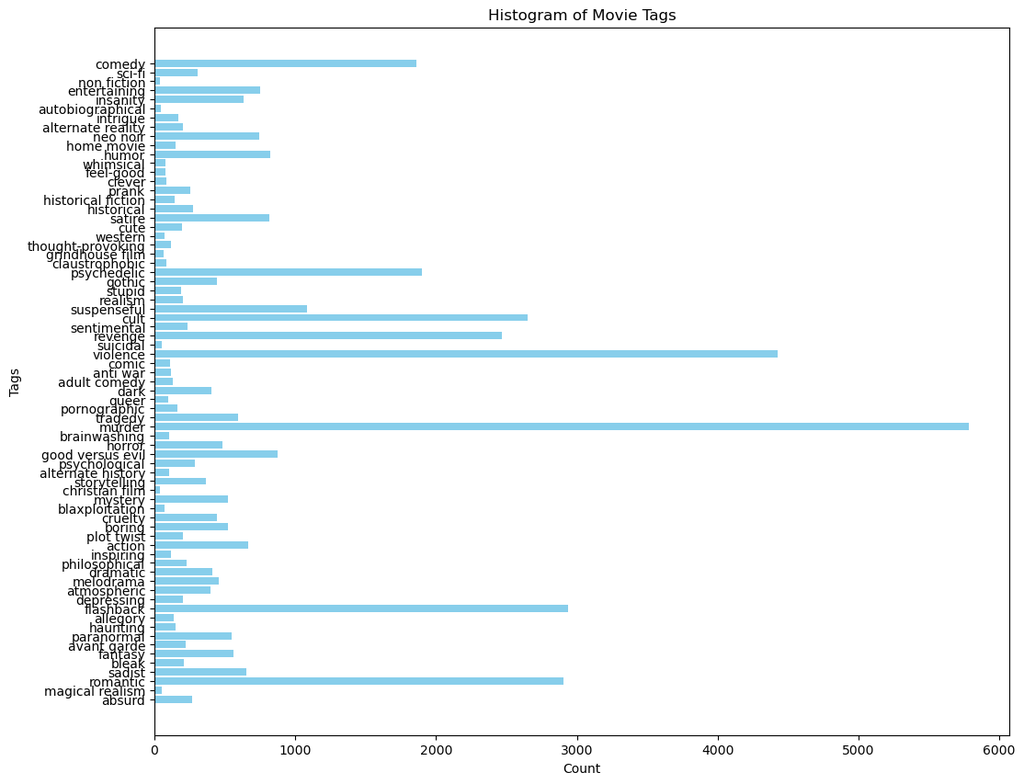

```python
# make plot
plt.figure(figsize=(12, 10))
plt.barh(tags_pd['tag'], tags_pd['count'], color='skyblue')
plt.xlabel('Count')
plt.ylabel('Tags')
plt.title('Histogram of Movie Tags')
plt.show()
```

```python
# 1d: histogram of top 10 tags in descending order

# order tag counts in desc order and get top 10
tags2 = tags.orderBy(F.desc("count")).limit(10)

tags2.show()
```

```
[Stage 44:>                                                         (0 + 1) / 1]
```

```
+----------------+-----+
|             tag|count|
+----------------+-----+
|          murder| 5782|
|        violence| 4426|
|       flashback| 2937|
|        romantic| 2906|
|            cult| 2647|
|         revenge| 2468|
|     psychedelic| 1897|
|          comedy| 1859|
|     suspenseful| 1086|
|good versus evil|  875|
+----------------+-----+
```

```python
# convert for plotting

tags2_pd = tags2.toPandas()
```

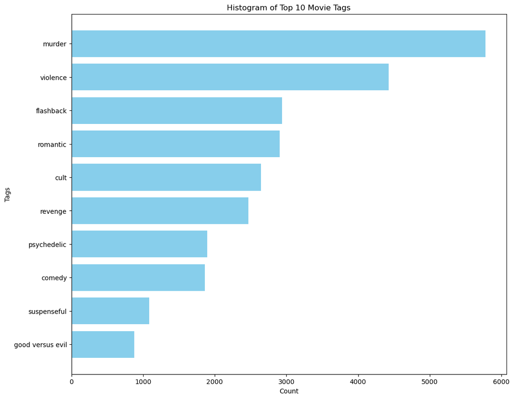

```python
# plot
plt.figure(figsize=(12, 10))
plt.barh(tags2_pd['tag'], tags2_pd['count'], color='skyblue')
plt.xlabel('Count')
plt.ylabel('Tags')
plt.title('Histogram of Top 10 Movie Tags')
plt.gca().invert_yaxis() # put highest bar on top
plt.show()
```

#### Question 2: NLP

##### First, tokenize the synopsis and remove stop words. Then pivot the data and retain one hot encoding for the top 10 tags.

```python
#tokenize words
tokenizer = Tokenizer(inputCol="plot_synopsis", outputCol="tokens")
clean_df = tokenizer.transform(df)

#drop the synopsis column
clean_df= clean_df.drop("plot_synopsis")
clean_df.show(5)
```

```
+---------+--------------------+--------------------+-----+---------------+--------------------+
|  imdb_id|               title|                tags|split|synopsis_source|              tokens|
+---------+--------------------+--------------------+-----+---------------+--------------------+
|tt0057603|I tre volti della...|cult, horror, got...|train|           imdb|[note:, this, syn...|
|tt1733125|Dungeons & Dragon...|            violence|train|           imdb|[two, thousand, y...|
|tt0033045|The Shop Around t...|            romantic| test|           imdb|[matuschek's,, a,...|
|tt0113862|  Mr. Holland's Opus|inspiring, romant...|train|           imdb|[glenn, holland,,...|
|tt0086250|            Scarface|cruelty, murder, ...|  val|           imdb|[in, may, 1980,, ...|
+---------+--------------------+--------------------+-----+---------------+--------------------+
only showing top 5 rows
```

```python
#remove stop words
remover = StopWordsRemover(inputCol="tokens", outputCol="filtered_toks")
clean_df = remover.transform(clean_df)

#drop the redundant source column
clean_df= clean_df.drop("tokens")
clean_df.show(5)
```

```
+---------+--------------------+--------------------+-----+---------------+--------------------+
|  imdb_id|               title|                tags|split|synopsis_source|       filtered_toks|
+---------+--------------------+--------------------+-----+---------------+--------------------+
|tt0057603|I tre volti della...|cult, horror, got...|train|           imdb|[note:, synopsis,...|
|tt1733125|Dungeons & Dragon...|            violence|train|           imdb|[two, thousand, y...|
|tt0033045|The Shop Around t...|            romantic| test|           imdb|[matuschek's,, gi...|
|tt0113862|  Mr. Holland's Opus|inspiring, romant...|train|           imdb|[glenn, holland,,...|
|tt0086250|            Scarface|cruelty, murder, ...|  val|           imdb|[may, 1980,, cuba...|
+---------+--------------------+--------------------+-----+---------------+--------------------+
only showing top 5 rows
```

```python
# pivoting the data

# explode the tags string to get one column for each tag
temp_df = clean_df.withColumn("tag", F.explode(F.split(F.col("tags"), ',\s*')))

# get unique tags
unique_tags = temp_df.select("tag").distinct().rdd.flatMap(lambda x: x).collect()

# one hot encoding for each tag
for tag in unique_tags:
    temp_df = temp_df.withColumn(tag, F.when(F.col('tag') == tag, 1).otherwise(0))

# check update worked
temp_df.show(5)
```

```
+---------+--------------------+--------------------+-----+---------------+--------------------+-----------+------+---------------+--------+------+-----+-------+-----------+----------+--------+--------+---------+----------+-----------+---------+--------+-------------+---------+------+----------+----…
|  imdb_id|               title|                tags|split|synopsis_source|       filtered_toks|        tag|absurd|magical realism|romantic|sadist|bleak|fantasy|avant garde|paranormal|haunting|allegory|flashback|depressing|atmospheric|melodrama|dramatic|philosophical|inspiring|action|plot twist|bori…
+---------+--------------------+--------------------+-----+---------------+--------------------+-----------+------+---------------+--------+------+-----+-------+-----------+----------+--------+--------+---------+----------+-----------+---------+--------+-------------+---------+------+----------+----…
|tt0057603|I tre volti della...|cult, horror, got...|train|           imdb|[note:, synopsis,...|       cult|     0|              0|       0|     0|    0|      0|          0|         0|       0|       0|        0|         0|          0|        0|       0|            0|        0|     0|         0|    …
|tt0057603|I tre volti della...|cult, horror, got...|train|           imdb|[note:, synopsis,...|     horror|     0|              0|       0|     0|    0|      0|          0|         0|       0|       0|        0|         0|          0|        0|       0|            0|        0|     0|         0|    …
|tt0057603|I tre volti della...|cult, horror, got...|train|           imdb|[note:, synopsis,...|     gothic|     0|              0|       0|     0|    0|      0|          0|         0|       0|       0|        0|         0|          0|        0|       0|            0|        0|     0|         0|    …
|tt0057603|I tre volti della...|cult, horror, got...|train|           imdb|[note:, synopsis,...|     murder|     0|              0|       0|     0|    0|      0|          0|         0|       0|       0|        0|         0|          0|        0|       0|            0|        0|     0|         0|    …
|tt0057603|I tre volti della...|cult, horror, got...|train|           imdb|[note:, synopsis,...|atmospheric|     0|              0|       0|     0|    0|      0|          0|         0|       0|       0|        0|         0|          1|        0|       0|            0|        0|     0|         0|    …
+---------+--------------------+--------------------+-----+---------------+--------------------+-----------+------+---------------+--------+------+-----+-------+-----------+----------+--------+--------+---------+----------+-----------+---------+--------+-------------+---------+------+----------+----…
only showing top 5 rows
```

```python
# only keep synopsis, title, split, and top 10 tag columns

clean_df = temp_df.select("filtered_toks", "title", "split", *tags2_pd['tag'].tolist())
```

```python
clean_df.show(10)
```

```
+--------------------+--------------------+-----+------+--------+---------+--------+----+-------+-----------+------+-----------+----------------+
|       filtered_toks|               title|split|murder|violence|flashback|romantic|cult|revenge|psychedelic|comedy|suspenseful|good versus evil|
+--------------------+--------------------+-----+------+--------+---------+--------+----+-------+-----------+------+-----------+----------------+
|[note:, synopsis,...|I tre volti della...|train|     0|       0|        0|       0|   1|      0|          0|     0|          0|               0|
|[note:, synopsis,...|I tre volti della...|train|     0|       0|        0|       0|   0|      0|          0|     0|          0|               0|
|[note:, synopsis,...|I tre volti della...|train|     0|       0|        0|       0|   0|      0|          0|     0|          0|               0|
|[note:, synopsis,...|I tre volti della...|train|     1|       0|        0|       0|   0|      0|          0|     0|          0|               0|
|[note:, synopsis,...|I tre volti della...|train|     0|       0|        0|       0|   0|      0|          0|     0|          0|               0|
|[two, thousand, y...|Dungeons & Dragon...|train|     0|       1|        0|       0|   0|      0|          0|     0|          0|               0|
|[matuschek's,, gi...|The Shop Around t...| test|     0|       0|        0|       1|   0|      0|          0|     0|          0|               0|
|[glenn, holland,,...|  Mr. Holland's Opus|train|     0|       0|        0|       0|   0|      0|          0|     0|          0|               0|
|[glenn, holland,,...|  Mr. Holland's Opus|train|     0|       0|        0|       1|   0|      0|          0|     0|          0|               0|
|[glenn, holland,,...|  Mr. Holland's Opus|train|     0|       0|        0|       0|   0|      0|          0|     0|          0|               0|
+--------------------+--------------------+-----+------+--------+---------+--------+----+-------+-----------+------+-----------+----------------+
only showing top 10 rows
```

##### Next, make two new dataframes using vectorization. We will use HashingTF and Word2Vec.

```python
# hash the tokens into features
hashingTF = HashingTF(inputCol="filtered_toks", outputCol="rawFeatures", numFeatures=20)
featurizedData = hashingTF.transform(clean_df)

idf = IDF(inputCol="rawFeatures", outputCol="features")
idfModel = idf.fit(featurizedData)
htf_df = idfModel.transform(featurizedData)
htf_df = htf_df.drop("rawFeatures")

htf_df.show(5)
```

```
+--------------------+--------------------+-----+------+--------+---------+--------+----+-------+-----------+------+-----------+----------------+--------------------+
|       filtered_toks|               title|split|murder|violence|flashback|romantic|cult|revenge|psychedelic|comedy|suspenseful|good versus evil|            features|
+--------------------+--------------------+-----+------+--------+---------+--------+----+-------+-----------+------+-----------+----------------+--------------------+
|[note:, synopsis,...|I tre volti della...|train|     0|       0|        0|       0|   1|      0|          0|     0|          0|               0|(20,[0,1,2,3,4,5,...|
|[note:, synopsis,...|I tre volti della...|train|     0|       0|        0|       0|   0|      0|          0|     0|          0|               0|(20,[0,1,2,3,4,5,...|
|[note:, synopsis,...|I tre volti della...|train|     0|       0|        0|       0|   0|      0|          0|     0|          0|               0|(20,[0,1,2,3,4,5,...|
|[note:, synopsis,...|I tre volti della...|train|     1|       0|        0|       0|   0|      0|          0|     0|          0|               0|(20,[0,1,2,3,4,5,...|
|[note:, synopsis,...|I tre volti della...|train|     0|       0|        0|       0|   0|      0|          0|     0|          0|               0|(20,[0,1,2,3,4,5,...|
+--------------------+--------------------+-----+------+--------+---------+--------+----+-------+-----------+------+-----------+----------------+--------------------+
only showing top 5 rows
```

```python
# word2vec vectorization
word2Vec = Word2Vec(vectorSize=5, minCount=0, inputCol="filtered_toks", outputCol="wordVectors")
w2VM = word2Vec.fit(clean_df)
w2v_df = w2VM.transform(clean_df)
```

```python
w2v_df.show(5)
```

```
[Stage 118:>                                                        (0 + 1) / 1]
```

```
+--------------------+--------------------+-----+------+--------+---------+--------+----+-------+-----------+------+-----------+----------------+--------------------+
|       filtered_toks|               title|split|murder|violence|flashback|romantic|cult|revenge|psychedelic|comedy|suspenseful|good versus evil|         wordVectors|
+--------------------+--------------------+-----+------+--------+---------+--------+----+-------+-----------+------+-----------+----------------+--------------------+
|[note:, synopsis,...|I tre volti della...|train|     0|       0|        0|       0|   1|      0|          0|     0|          0|               0|[-0.2064644122025...|
|[note:, synopsis,...|I tre volti della...|train|     0|       0|        0|       0|   0|      0|          0|     0|          0|               0|[-0.2064644122025...|
|[note:, synopsis,...|I tre volti della...|train|     0|       0|        0|       0|   0|      0|          0|     0|          0|               0|[-0.2064644122025...|
|[note:, synopsis,...|I tre volti della...|train|     1|       0|        0|       0|   0|      0|          0|     0|          0|               0|[-0.2064644122025...|
|[note:, synopsis,...|I tre volti della...|train|     0|       0|        0|       0|   0|      0|          0|     0|          0|               0|[-0.2064644122025...|
+--------------------+--------------------+-----+------+--------+---------+--------+----+-------+-----------+------+-----------+----------------+--------------------+
only showing top 5 rows
```

##### Next, split each vectorized df into train, test, and val dataframes (6 total dataframes).

```python
# split htf df
htf_train_df = htf_df.filter(F.col('split') == 'train')
htf_test_df = htf_df.filter(F.col('split') == 'test')
htf_val_df = htf_df.filter(F.col('split') == 'val')
```

```python
# check split column
htf_train_df.select("split").show(5)
```

```
+-----+
|split|
+-----+
|train|
|train|
|train|
|train|
|train|
+-----+
only showing top 5 rows
```

```
[Stage 107:>                                                        (0 + 1) / 1]
```

```python
htf_test_df.select("split").show(5)
```

```
+-----+
|split|
+-----+
| test|
| test|
| test|
| test|
| test|
+-----+
only showing top 5 rows
```

```
[Stage 107:>                                                        (0 + 1) / 1]
```

```python
htf_val_df.select("split").show(5)
```

```
+-----+
|split|
+-----+
|  val|
|  val|
|  val|
|  val|
|  val|
+-----+
only showing top 5 rows
```

```
[Stage 107:>                                                        (0 + 1) / 1]
```

```python
# split w2v df
w2v_train_df = w2v_df.filter(F.col('split') == 'train')
w2v_test_df = w2v_df.filter(F.col('split') == 'test')
w2v_val_df = w2v_df.filter(F.col('split') == 'val')
```

```python
# check split col
w2v_train_df.select("split").show(5)
```

```
+-----+
|split|
+-----+
|train|
|train|
|train|
|train|
|train|
+-----+
only showing top 5 rows
```

```python
w2v_test_df.select("split").show(5)
```

```
+-----+
|split|
+-----+
| test|
| test|
| test|
| test|
| test|
+-----+
only showing top 5 rows
```

```python
w2v_val_df.select("split").show(5)
```

```
+-----+
|split|
+-----+
|  val|
|  val|
|  val|
|  val|
|  val|
+-----+
only showing top 5 rows
```

##### Build Models: using a for loop, build a logistic regression model that predicts a label of 0 or 1 for a certain tag and repeat this for all tags. Do this for both vectorization methods for comparison.

```python
# models for HTF vectorization

res_df = [] # store metric results for each model in this
tags = tags2_pd['tag'].tolist() # list of top 10 tags

evaluator_f1 = MulticlassClassificationEvaluator(metricName='f1')
evaluator_accuracy = MulticlassClassificationEvaluator(metricName='accuracy')


# Loop through each tag and run a logistic regression model on the train, val, and test dfs
for tag in tags:
    # initialize model
    lgr = LogisticRegression(maxIter = 20, featuresCol = 'features', labelCol = tag)

    # train model
    lgrm = lgr.fit(htf_train_df)

    # run model on val and test dfs
    val_preds = lgrm.transform(htf_val_df)
    test_preds = lgrm.transform(htf_test_df)

    # evaluate model
    val_f1 = evaluator_f1.evaluate(val_preds, {evaluator_f1.labelCol: tag,
                                               evaluator_f1.predictionCol: 'prediction'})
    val_accuracy = evaluator_accuracy.evaluate(val_preds, {evaluator_accuracy.labelCol: tag,
                                                           evaluator_accuracy.predictionCol: 'prediction'})
    test_f1 = evaluator_f1.evaluate(test_preds, {evaluator_f1.labelCol: tag,
                                                 evaluator_f1.predictionCol: 'prediction'})
    test_accuracy = evaluator_accuracy.evaluate(test_preds, {evaluator_accuracy.labelCol: tag,
                                                             evaluator_accuracy.predictionCol: 'prediction'})

    # add results
    res_df.append(Row(tag = tag, val_f1 = val_f1, val_accuracy = val_accuracy, test_f1 = test_f1,
                          test_accuracy = test_accuracy))

# create and show res df
res_df = spark.createDataFrame(res_df)
res_df.show(res_df.count(), truncate = False)
```

```
+----------------+------------------+------------------+------------------+------------------+
|tag             |val_f1            |val_accuracy      |test_f1           |test_accuracy     |
+----------------+------------------+------------------+------------------+------------------+
|murder          |0.8097300816609753|0.8701480033510193|0.8123469187936058|0.8719796054090002|
|violence        |0.855499655578753 |0.9019826864004468|0.8512214537398759|0.8990246065174019|
|flashback       |0.8981779034616378|0.9313041049986037|0.9020371619997416|0.9339392595876745|
|romantic        |0.9028815923811375|0.9345154984641162|0.9034991219581796|0.934936821103968 |
|cult            |0.9137421747106309|0.9419156660150796|0.9093524479494429|0.9389270671691421|
|revenge         |0.916000017574855 |0.9434515498464117|0.9165183730931012|0.9438040345821326|
|psychedelic     |0.9339025445790715|0.9555989946942195|0.934817138340601 |0.9562181334515628|
|comedy          |0.9382357243093251|0.9585311365540352|0.9392408258628464|0.9592108180004434|
|suspenseful     |0.9589323618295098|0.9724937168388719|0.9622543685808388|0.9747284415872313|
|good versus evil|0.9713992580099614|0.9808712650097738|0.9680624204892588|0.9776102859676347|
+----------------+------------------+------------------+------------------+------------------+
```

```python
# models for word2vec vectorization

res_df = [] # store metric results for each model in this
tags = tags2_pd['tag'].tolist() # list of top 10 tags

evaluator_f1 = MulticlassClassificationEvaluator(metricName='f1')
evaluator_accuracy = MulticlassClassificationEvaluator(metricName='accuracy')


# Loop through each tag and run a logistic regression model on the train, val, and test dfs
for tag in tags:
    # initialize model
    lgr = LogisticRegression(maxIter = 20, featuresCol = 'wordVectors', labelCol = tag)

    # train model
    lgrm = lgr.fit(w2v_train_df)

    # run model on val and test dfs
    val_preds = lgrm.transform(w2v_val_df)
    test_preds = lgrm.transform(w2v_test_df)

    # evaluate model
    val_f1 = evaluator_f1.evaluate(val_preds, {evaluator_f1.labelCol: tag,
                                               evaluator_f1.predictionCol: 'prediction'})
    val_accuracy = evaluator_accuracy.evaluate(val_preds, {evaluator_accuracy.labelCol: tag,
                                                           evaluator_accuracy.predictionCol: 'prediction'})
    test_f1 = evaluator_f1.evaluate(test_preds, {evaluator_f1.labelCol: tag,
                                                 evaluator_f1.predictionCol: 'prediction'})
    test_accuracy = evaluator_accuracy.evaluate(test_preds, {evaluator_accuracy.labelCol: tag,
                                                             evaluator_accuracy.predictionCol: 'prediction'})

    # add results
    res_df.append(Row(tag = tag, val_f1 = val_f1, val_accuracy = val_accuracy, test_f1 = test_f1,
                          test_accuracy = test_accuracy))

# create and show res df
res_df = spark.createDataFrame(res_df)
res_df.show(res_df.count(), truncate = False)
```

```
+----------------+------------------+------------------+------------------+------------------+
|tag             |val_f1            |val_accuracy      |test_f1           |test_accuracy     |
+----------------+------------------+------------------+------------------+------------------+
|murder          |0.8103945746554552|0.8698687517453225|0.8122917546360962|0.8718687652405231|
|violence        |0.855499655578753 |0.9019826864004468|0.8512214537398759|0.8990246065174019|
|flashback       |0.8981779034616378|0.9313041049986037|0.9020371619997416|0.9339392595876745|
|romantic        |0.9028815923811375|0.9345154984641162|0.9034991219581796|0.934936821103968 |
|cult            |0.9137421747106309|0.9419156660150796|0.9093524479494429|0.9389270671691421|
|revenge         |0.916000017574855 |0.9434515498464117|0.9165183730931012|0.9438040345821326|
|psychedelic     |0.9339025445790715|0.9555989946942195|0.934817138340601 |0.9562181334515628|
|comedy          |0.9382357243093251|0.9585311365540352|0.9392408258628464|0.9592108180004434|
|suspenseful     |0.9589323618295098|0.9724937168388719|0.9622543685808388|0.9747284415872313|
|good versus evil|0.9713992580099614|0.9808712650097738|0.9685226089483613|0.9789403679893594|
+----------------+------------------+------------------+------------------+------------------+
```

#### Question 3

##### I used the information on the website https://www.imdb.com/list/ls565690655/ to create a csv with movie titles and synopsis data and then I uploaded it to the gcs bucket.

```python
# 1a: read in data
new_df = spark.read.option("header", True) \
    .option("inferSchema", True) \
    .option("multiLine", True) \
    .option("escape", '"') \
    .option("quote", '"') \
    .csv("gs://msca-31013-bdp-ap-datasets/new_movies_5.csv")
```

```python
new_df.show() # check df
```

```
+--------------------+--------------------+
|               title|            synopsis|
+--------------------+--------------------+
|         Terrifier 2|After being resur...|
|                   X|In 1979, a group ...|
|               Smile|After witnessing ...|
|               Pearl|In 1918, a young ...|
|Spider-Man: No Wa...|With Spider-Man's...|
|              Scream|25 years after a ...|
|        Bullet Train|Five assassins ab...|
|Thor: Love and Th...|Thor enlists the ...|
|            The Menu|A young couple tr...|
|Everything Everyw...|A middle-aged Chi...|
+--------------------+--------------------+
```

```python
new_df.printSchema() # make sure columns are loaded as strings
```

```
root
 |-- title: string (nullable = true)
 |-- synopsis: string (nullable = true)
```

```python
# remove stop words, tokenize, and use hashing vectorization


#tokenize words
tokenizer = Tokenizer(inputCol="synopsis", outputCol="tokens")
new_clean_df = tokenizer.transform(new_df)

#drop the synopsis column
new_clean_df= new_clean_df.drop("synopsis")

#remove stop words
remover = StopWordsRemover(inputCol="tokens", outputCol="filtered_toks")
new_clean_df = remover.transform(new_clean_df)

#drop the redundant source column
new_clean_df= new_clean_df.drop("tokens")


# hash the tokens into features
hashingTF = HashingTF(inputCol="filtered_toks", outputCol="rawFeatures", numFeatures=20)
featurizedData = hashingTF.transform(new_clean_df)

idf = IDF(inputCol="rawFeatures", outputCol="features")
idfModel = idf.fit(featurizedData)
new_htf_df = idfModel.transform(featurizedData)
new_htf_df = new_htf_df.drop("rawFeatures")

new_htf_df.show(5)
```

```
+--------------------+--------------------+--------------------+
|               title|       filtered_toks|            features|
+--------------------+--------------------+--------------------+
|         Terrifier 2|[resurrected, sin...|(20,[1,2,4,7,8,9,...|
|                   X|[1979,, group, yo...|(20,[0,1,2,3,5,6,...|
|               Smile|[witnessing, biza...|(20,[0,1,3,5,9,10...|
|               Pearl|[1918,, young, wo...|(20,[0,1,2,3,4,6,...|
|Spider-Man: No Wa...|[spider-man's, id...|(20,[0,1,3,4,9,11...|
+--------------------+--------------------+--------------------+
only showing top 5 rows
```

```python
# running htf models

# top 10 list
tags = tags2_pd['tag'].tolist()

# predictions df for new movies
res_df = []

# Loop through each tag and train a Logistic Regression model, then predict for new movies
for tag in tags:
    # Initialize the Logistic Regression model
    lgr = LogisticRegression(maxIter=20, featuresCol='features', labelCol=tag)

    # Train the model using the htf_train_df DataFrame
    lgrm = lgr.fit(htf_train_df)

    # Make predictions on the new movies
    preds = lgrm.transform(new_htf_df)

    # add results
    res_df.append(preds.select('title', 'prediction').withColumnRenamed('prediction', tag))
```

```python
# create final dataframe for results
res2_df = res_df[0]
for movie in res_df[1:]:
    res2_df = res2_df.join(movie, on='title', how='left')

res2_df.show(truncate=False)
```

```
[Stage 1225:>                                                       (0 + 1) / 1]
```

```
+---------------------------------+------+--------+---------+--------+----+-------+-----------+------+-----------+----------------+
|title                            |murder|violence|flashback|romantic|cult|revenge|psychedelic|comedy|suspenseful|good versus evil|
+---------------------------------+------+--------+---------+--------+----+-------+-----------+------+-----------+----------------+
|Terrifier 2                      |0.0   |0.0     |0.0      |1.0     |0.0 |0.0    |1.0        |0.0   |0.0        |1.0             |
|X                                |0.0   |0.0     |1.0      |1.0     |0.0 |0.0    |0.0        |0.0   |0.0        |0.0             |
|Smile                            |0.0   |0.0     |1.0      |1.0     |0.0 |0.0    |0.0        |0.0   |0.0        |0.0             |
|Pearl                            |0.0   |0.0     |1.0      |1.0     |0.0 |0.0    |0.0        |0.0   |0.0        |1.0             |
|Spider-Man: No Way Home          |0.0   |0.0     |1.0      |1.0     |0.0 |0.0    |0.0        |0.0   |0.0        |0.0             |
|Scream                           |0.0   |0.0     |0.0      |0.0     |1.0 |0.0    |1.0        |0.0   |0.0        |1.0             |
|Bullet Train                     |1.0   |0.0     |0.0      |0.0     |1.0 |0.0    |1.0        |0.0   |0.0        |1.0             |
|Thor: Love and Thunder           |0.0   |0.0     |1.0      |1.0     |0.0 |0.0    |0.0        |1.0   |0.0        |0.0             |
|The Menu                         |0.0   |1.0     |1.0      |0.0     |0.0 |1.0    |0.0        |0.0   |0.0        |1.0             |
|Everything Everywhere All at once|0.0   |0.0     |1.0      |1.0     |0.0 |1.0    |0.0        |1.0   |0.0        |0.0             |
+---------------------------------+------+--------+---------+--------+----+-------+-----------+------+-----------+----------------+
```

##### All of the 10 movies were labeled with at least one tag. To make this model generalize better, we could use a better vectorizing method and/or use more tags rather than the top 10 tags in the original movie data set. In the original dataset there are way more than 10 tags so we could either use all of these tags in our model or we can make better groupings of similar tags and use those groupings as the new tags in our model to capture patterns better for improved generalizability.